# AllLife Bank - Personal Loan Campaign

## Loan Modeling

### Background and Context

AllLife Bank is a US bank with a growing customer base. The majority of these customers are liability customers (depositors). The number of customers who are also borrowers (asset customers) is quite small, and the bank is looking at expanding this base rapidly to bring in more loan business and earn more through the interest. Management wants to explore ways of converting its liability customers to personal loan customers (while retaining them as depositors).

A campaign run last year for liability customers showed a healthy conversion rate of over 9% success. This has encouraged the retail marketing department to devise campaigns with better target marketing to increase the success ratio.

### My Objective

As a Data Scientist for AllLife Bank I am going to use Exploratory Data Analysis, Logistic Regression models, Decision Tree models, and model tuning methods to find out which variables in the dataset are most significant at predicting whether or not a customer will purchase a personal loan. I will then use my findings, from these models, to make my reccomendations to the marketing department as to which customer segment should be targeted.

### Data Dictionary

- ID: Customer ID
- Age: Customer’s age in completed years
- Experience: #years of professional experience
- Income: Annual income of the customer (in thousand dollars)
- ZIP Code: Home Address ZIP code.
- Family: the Family size of the customer
- CCAvg: Average spending on credit cards per month (in thousand dollars)
- Education: Education Level. 1: Undergrad; 2: Graduate; 3: Advanced/Professional
- Mortgage: Value of house mortgage if any. (in thousand dollars)
- Personal_Loan: Did this customer accept the personal loan offered in the last campaign?
- Securities_Account: Does the customer have a securities account with the bank?
- CD_Account: Does the customer have a certificate of deposit (CD) account with the bank?
- Online: Do customers use internet banking facilities?
- CreditCard: Does the customer use a credit card issued by any other Bank (excluding All life Bank)?

# Import Libraries

```python
import numpy as np
import pandas as pd
import matplotlib.pyplot as plt
%matplotlib inline
import seaborn as sns
```

```python
# setting limit for max columns shown to None
# setting limits for max rows shown to 200
pd.set_option('display.max_columns', None)
pd.set_option('display.max_rows', 200)
```

```python
# for model building
from sklearn.model_selection import train_test_split
from sklearn.linear_model import LogisticRegression

# for decision tree
from sklearn.tree import DecisionTreeClassifier
from sklearn import tree

# for model tuning
from sklearn.model_selection import GridSearchCV

# for metric scores to evaluate model performance
from sklearn.metrics import (
    f1_score,
    accuracy_score,
    recall_score,
    precision_score,
    confusion_matrix,
    plot_confusion_matrix,
    make_scorer,
    roc_auc_score,
    precision_recall_curve,
    roc_curve
)
```

# Import Data

```python
from google.colab import drive
drive.mount('/content/drive')
```

```python
data = pd.read_csv('/content/drive/MyDrive/Python Course/Loan_Modelling.csv')
```

```python
loan = data.copy()
```

```python
loan.head()
```

|  | ID | Age | Experience | Income | ZIPCode | Family | CCAvg | Education | Mortgage | Personal_Loan | Securities_Account | CD_Account | Online | CreditCard |
| --- | --- | --- | --- | --- | --- | --- | --- | --- | --- | --- | --- | --- | --- | --- |
| 0 | 1 | 25 | 1 | 49 | 91107 | 4 | 1.6 | 1 | 0 | 0 | 1 | 0 | 0 | 0 |
| 1 | 2 | 45 | 19 | 34 | 90089 | 3 | 1.5 | 1 | 0 | 0 | 1 | 0 | 0 | 0 |
| 2 | 3 | 39 | 15 | 11 | 94720 | 1 | 1.0 | 1 | 0 | 0 | 0 | 0 | 0 | 0 |
| 3 | 4 | 35 | 9 | 100 | 94112 | 1 | 2.7 | 2 | 0 | 0 | 0 | 0 | 0 | 0 |
| 4 | 5 | 35 | 8 | 45 | 91330 | 4 | 1.0 | 2 | 0 | 0 | 0 | 0 | 0 | 1 |

- Dataset imported properly

# Data Overview

```python
loan.shape
```

```
(5000, 14)
```

- We have 14 different variables (columns) for information on 5000 customers of AllLife Bank (rows)

```python
# check data type for our variables
loan.info()
```

```
<class 'pandas.core.frame.DataFrame'>
RangeIndex: 5000 entries, 0 to 4999
Data columns (total 14 columns):
 #   Column              Non-Null Count  Dtype
---  ------              --------------  -----
 0   ID                  5000 non-null   int64
 1   Age                 5000 non-null   int64
 2   Experience          5000 non-null   int64
 3   Income              5000 non-null   int64
 4   ZIPCode             5000 non-null   int64
 5   Family              5000 non-null   int64
 6   CCAvg               5000 non-null   float64
 7   Education           5000 non-null   int64
 8   Mortgage            5000 non-null   int64
 9   Personal_Loan       5000 non-null   int64
 10  Securities_Account  5000 non-null   int64
 11  CD_Account          5000 non-null   int64
 12  Online              5000 non-null   int64
 13  CreditCard          5000 non-null   int64
dtypes: float64(1), int64(13)
memory usage: 547.0 KB
```

- Out of our 14 columns all are numerical in nature with the data type being integer for all but 1 column, CCAvg which is a float type numerical variable.
- Some of these variables are not going to work as numeric variables. ZIPCode as a numric variable is not giving us information in a form that will be useful to understand any location trends for customers so we will need to find a way to make this categorical.
- Personal_Loan is our dependent variable. It is an integer type with a 1 or 0 entry for whether or not the customer accepted a Personal_Loan yes or no.
- Columns 10-13 are also all yes or no entries being indicated by a 1 or 0.
- It appears that we have no missing values for any of our variables as all are showing a non-null count of 5000 which is equal to the total number of rows in the dataset.

```python
# check numerical statistics for our variables
loan.describe().T
```

|  | count | mean | std | min | 25% | 50% | 75% | max |
| --- | --- | --- | --- | --- | --- | --- | --- | --- |
| ID | 5000.0 | 2500.500000 | 1443.520003 | 1.0 | 1250.75 | 2500.5 | 3750.25 | 5000.0 |
| Age | 5000.0 | 45.338400 | 11.463166 | 23.0 | 35.00 | 45.0 | 55.00 | 67.0 |
| Experience | 5000.0 | 20.104600 | 11.467954 | -3.0 | 10.00 | 20.0 | 30.00 | 43.0 |
| Income | 5000.0 | 73.774200 | 46.033729 | 8.0 | 39.00 | 64.0 | 98.00 | 224.0 |
| ZIPCode | 5000.0 | 93169.257000 | 1759.455086 | 90005.0 | 91911.00 | 93437.0 | 94608.00 | 96651.0 |
| Family | 5000.0 | 2.396400 | 1.147663 | 1.0 | 1.00 | 2.0 | 3.00 | 4.0 |
| CCAvg | 5000.0 | 1.937938 | 1.747659 | 0.0 | 0.70 | 1.5 | 2.50 | 10.0 |
| Education | 5000.0 | 1.881000 | 0.839869 | 1.0 | 1.00 | 2.0 | 3.00 | 3.0 |
| Mortgage | 5000.0 | 56.498800 | 101.713802 | 0.0 | 0.00 | 0.0 | 101.00 | 635.0 |
| Personal_Loan | 5000.0 | 0.096000 | 0.294621 | 0.0 | 0.00 | 0.0 | 0.00 | 1.0 |
| Securities_Account | 5000.0 | 0.104400 | 0.305809 | 0.0 | 0.00 | 0.0 | 0.00 | 1.0 |
| CD_Account | 5000.0 | 0.060400 | 0.238250 | 0.0 | 0.00 | 0.0 | 0.00 | 1.0 |
| Online | 5000.0 | 0.596800 | 0.490589 | 0.0 | 0.00 | 1.0 | 1.00 | 1.0 |
| CreditCard | 5000.0 | 0.294000 | 0.455637 | 0.0 | 0.00 | 0.0 | 1.00 | 1.0 |

- The mean Age for customers is 45
- Most customers have an average of 20 years work Experience. The min. for work Experience is showing as -3.0, this is a clear problem as there shouldn't be negative years of Experience. We will need to find a way to treat this.
- Mean Income is 73,000. Max income is 224,000 which seems like an outlier since the 75th percentile is only 98,000. This is more than likely accurate customer data which we want to keep, but it may be having an effect on the mean and also be skewing the data. This is something to keep in mind as we look at Income.
- It seems that Mortgage amount has a 0 for min. value, 25th percentile, and median. This shows that a significant amount of customers have zero for the value amount of their Mortgage. I interpret this as a large number of customers not owning a house therefore not having a mortgage value. This is certainly having a large effect on the mean value and skewing the data. We will need to take a further look at this and find a good way to treat the data.

```python
# check on unique values for 'ID'
loan['ID'].nunique()
```

```
5000
```

- all values of 'ID' are unique confirming that it is the same as the index, therefore we do not need it for our model and it can be dropped.

```python
loan.drop(['ID'], axis=1, inplace=True)
```

```python
loan.head()
```

|  | Age | Experience | Income | ZIPCode | Family | CCAvg | Education | Mortgage | Personal_Loan | Securities_Account | CD_Account | Online | CreditCard |
| --- | --- | --- | --- | --- | --- | --- | --- | --- | --- | --- | --- | --- | --- |
| 0 | 25 | 1 | 49 | 91107 | 4 | 1.6 | 1 | 0 | 0 | 1 | 0 | 0 | 0 |
| 1 | 45 | 19 | 34 | 90089 | 3 | 1.5 | 1 | 0 | 0 | 1 | 0 | 0 | 0 |
| 2 | 39 | 15 | 11 | 94720 | 1 | 1.0 | 1 | 0 | 0 | 0 | 0 | 0 | 0 |
| 3 | 35 | 9 | 100 | 94112 | 1 | 2.7 | 2 | 0 | 0 | 0 | 0 | 0 | 0 |
| 4 | 35 | 8 | 45 | 91330 | 4 | 1.0 | 2 | 0 | 0 | 0 | 0 | 0 | 1 |

- 'ID' column has been removed successfully

### Converitng ZIPCode into categorical variable

```python
# install zipcode package
!pip install uszipcode
```

```
     |████████████████████████████████| 120 kB 9.0 MB/s
     |████████████████████████████████| 76 kB 4.9 MB/s
     |████████████████████████████████| 45 kB 3.7 MB/s
     |████████████████████████████████| 41 kB 308 kB/s
```

```python
# import SearchEngine from uszipcode package
from uszipcode import SearchEngine
```

```python
# convert 'ZIPCode' to string type variable
loan['ZIPCode'] = loan['ZIPCode'].values.astype(str)
```

Using SearchEngine from zipcode package to create a new column called 'County' with the names of the county for each zipcode in the data

```python
search = SearchEngine()
county = []
missing_zipcodes = []

for i in loan['ZIPCode']:
    zipcode = search.by_zipcode(str(i))
    if zipcode is None:
      missing_zipcodes.append(str(i))
      county.append('missing')

    else:
      county.append(zipcode.county)

loan['County'] = county
print(set(missing_zipcodes))
```

[output not shown]

### Now we can drop the ZIPCode column

```python
loan.drop(['ZIPCode'], axis=1, inplace=True)
```

```python
loan.head()
```

|  | Age | Experience | Income | Family | CCAvg | Education | Mortgage | Personal_Loan | Securities_Account | CD_Account | Online | CreditCard | County |
| --- | --- | --- | --- | --- | --- | --- | --- | --- | --- | --- | --- | --- | --- |
| 0 | 25 | 1 | 49 | 4 | 1.6 | 1 | 0 | 0 | 1 | 0 | 0 | 0 | Los Angeles County |
| 1 | 45 | 19 | 34 | 3 | 1.5 | 1 | 0 | 0 | 1 | 0 | 0 | 0 | Los Angeles County |
| 2 | 39 | 15 | 11 | 1 | 1.0 | 1 | 0 | 0 | 0 | 0 | 0 | 0 | Alameda County |
| 3 | 35 | 9 | 100 | 1 | 2.7 | 2 | 0 | 0 | 0 | 0 | 0 | 0 | San Francisco County |
| 4 | 35 | 8 | 45 | 4 | 1.0 | 2 | 0 | 0 | 0 | 0 | 0 | 1 | Los Angeles County |

- 'ZIPCode' column was dropped successfully and we can see the new 'County' column on the end which is correctly displaying the county name for the each customer based on their zipcode.

# Exploratory Data Analysis

## Univariate Analysis

```python
# creating a code to create a histogram and boxplot for each of our variables
def histogram_boxplot(data, feature, figsize=(12,7), kde=False, bins=None):
    """
    Creating a histogram and boxplot

    data: dataframe
    feature: loan[column]
    figsize: size of figure
    kde: show density curve (default: False)
    bins: number of bins for histogram (default: None)
    """
    f2, (ax_box2, ax_hist2) = plt.subplots(
        nrows=2,  # rows of subplot grid= 2
        sharex=True,  # subplots share x-axis
        gridspec_kw={'height_ratios': (0.25, 0.75)},
        figsize=figsize,
    ) # create subplots
    sns.boxplot(
        data=loan, x=feature, ax=ax_box2, showmeans=True, color='yellow'
    ) # boxplot will have a green triangle representing the mean
    sns.histplot(
        data=loan, x=feature, kde=kde, ax=ax_hist2, bins=bins, pallete='winter'
    )   if bins else sns.histplot(
        data=data, x=feature, kde=kde, ax=ax_hist2
    )
    ax_hist2.axvline(
        data[feature].mean(), color='red', linestyle='--'
    ) # Add mean line to histogram
    ax_hist2.axvline(
        data[feature].median(), color='black', linestyle='-'
    ) # Add median line to histogram
```

# Age

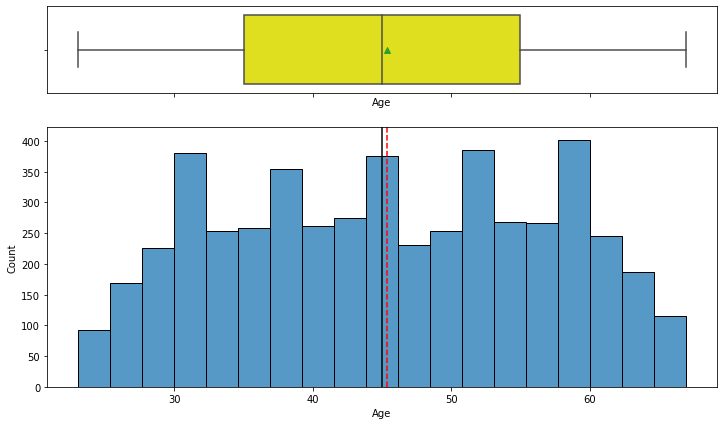

```python
histogram_boxplot(loan, 'Age')
```

Age is pretty evenly distributed with no real skewness or outliers

# Experience

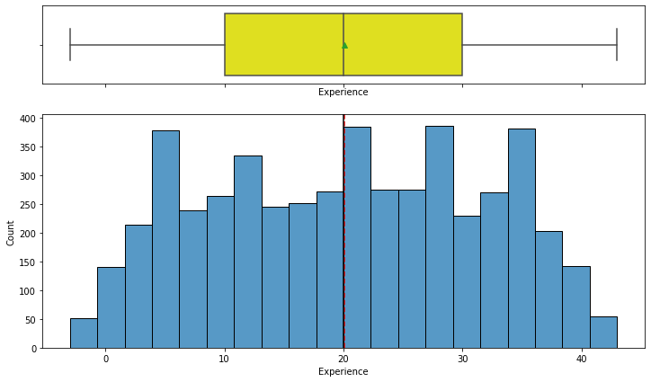

```python
histogram_boxplot(loan, 'Experience')
```

- experience also has a fairly even distribution with no real outliers or skewness
- we do have the issue though where there are negative values for years of experience so we need to correct that

```python
# let's check what we have for negative values
loan['Experience'].value_counts()
```

```
 32    154
 20    148
 9     147
 5     146
 23    144
 35    143
 25    142
 28    138
 18    137
 19    135
 26    134
 24    131
 3     129
 16    127
 14    127
```

[output cut: 33 more lines]

- It looks like we have 33 customers showing -1 years of Experience, 15 with -2 years, and 4 with -3 years.
- There are 2 possible explanations here. 1. The data was entered correctly for the number of years, but with a negative sign by mistake, so all these customers have 1, 2, or 3 years of experience, respectively, and we can just remove the negative sign. 2. It is probably safer to assume they were just data collection/entry errors altogether and replace them with missing values and then impute them with the mean in this case as it is a fairly normal distribution and the mean and median are both 20 years Experience in this case.
- In this case I think it is safer to assume it was incorrect data and replace the values as missing and then impute them.

```python
# replacing negative values with np.nan for missing values
loan['Experience'] = loan['Experience'].replace([-1, -2, -3], np.nan)
```

- We saw in the histogram and barplot above that 20 was both the mean and median for Experience.
- I am going to use 20 to fill the missing values instead of ['Experience].mean() because it will give me a deicmal, not 20 even, and since all other experience in years are exact values, it needs to be as well.

```python
# filling in the missing values with the mean for 'Experience'
loan['Experience'] = loan['Experience'].fillna(20)
```

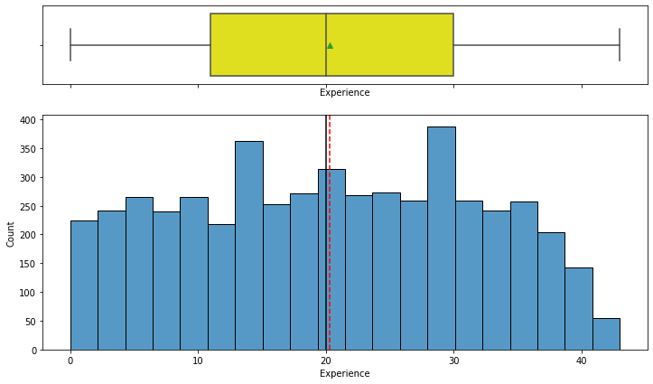

```python
histogram_boxplot(loan, 'Experience')
```

- Now with the negative values replaced with the mean, we do see a small right skew to the data

# Income

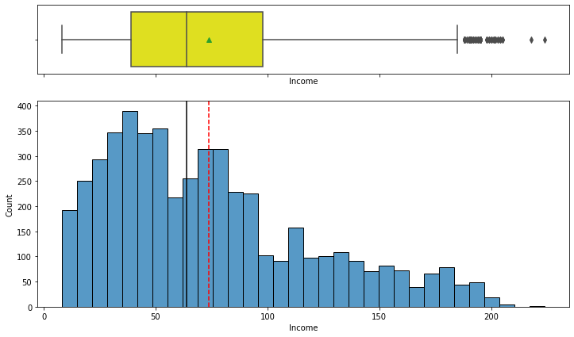

```python
histogram_boxplot(loan, 'Income')
```

- Income has a strong right skew with many outliers
- We do not want to treat any of these outliers as they are valuable data points on customer income

# Family

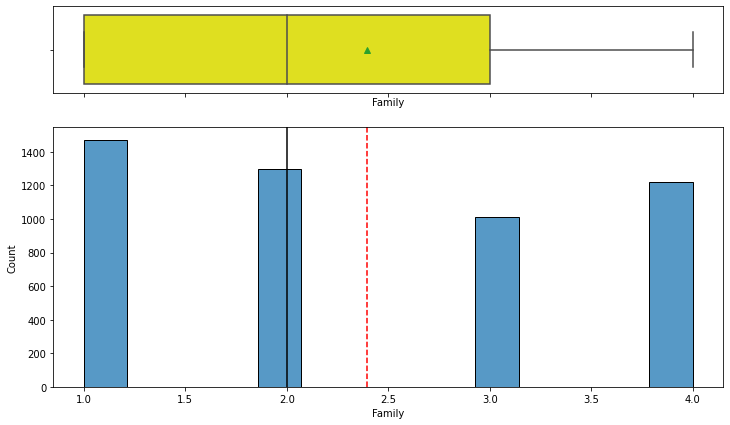

```python
histogram_boxplot(loan, 'Family')
```

- Single customers are the largest category followed closely by customers with a 2 person family size, then 4 person families, and 3 person families as the lowest of the 4 categories here.
- Overall the 4 categories are not too far apart from each other so there is a fairly good mix of family size in the data with the median being 2 person families.

# CCAvg

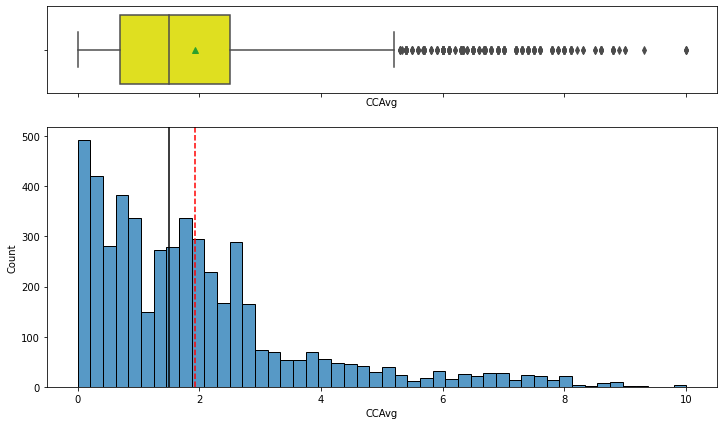

```python
histogram_boxplot(loan, 'CCAvg')
```

- The average spending on credit cards per month is very right skewed
- The mean spending for customers is a little less than 2,000 a month
- There are a lot of outliers in the data with any spending over 5,000 a month being considered an outlier. The outliers show spending going as high as 10,000 a month, which is 5x the average monthly spending done on credit cards.

# Education

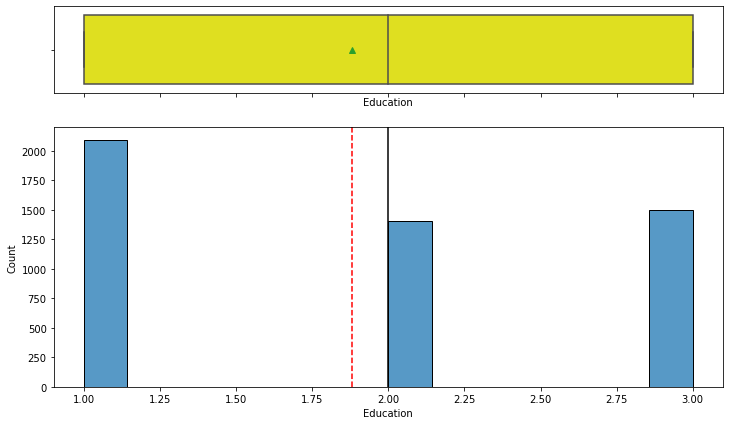

```python
histogram_boxplot(loan, 'Education')
```

- The largest category for Education is 1 which signifies an undergraduate level of education
- 3 is the next highest which signifies an Advanced/Professional education higher than Graduate level
- 2 is the lowest at Graduate level education

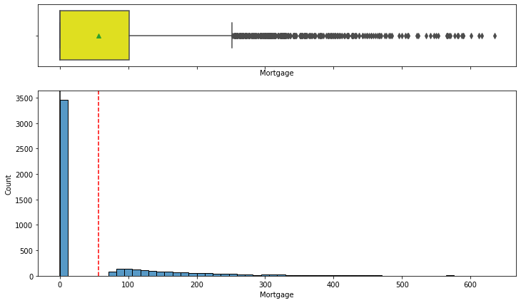

```python
histogram_boxplot(loan, 'Mortgage')
```

- Mortgage is extremely right skewed with a very high amount of outliers, but this is due to a little over 2/3rds of customers showing a value of 0 for mortgage which means they either are renting or possibly have already paid off their mortgage.
- Because of the high amount having no mortgage value, it may be better to turn this into a categorical variable asking if the customer has a mortgage yes or no. I think in this case having a mortgage or not would be a much more valuable metric than only looking at the specific mortgage values for the roughly 1/3 of the data set who have a mortgage value.

```python
loan['Mortgage'] = loan['Mortgage'].astype(bool).astype(int)
```

```python
loan['Mortgage'].value_counts()
```

```
0    3462
1    1538
Name: Mortgage, dtype: int64
```

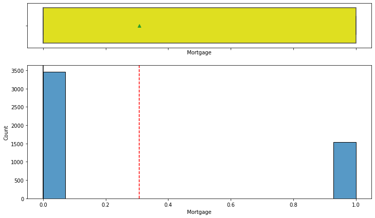

```python
histogram_boxplot(loan, 'Mortgage')
```

- We can now see how big the difference is between those who have a mortgae value as 1, and those who do not have a mortgage at 0
- We no longer have any outliers as it is a yes or no category now

# Personal Loan

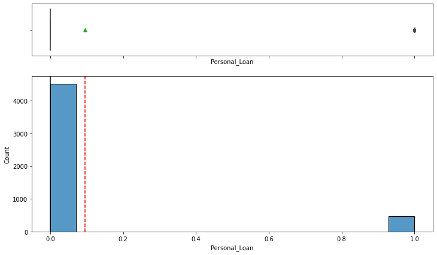

```python
histogram_boxplot(loan, 'Personal_Loan')
```

- out of 5000 customers only about 500 (1) accepted the loan offered in the last campaign, while about 4500 (0) did not accept the loan.
- This is our dependent variable as finding out what factors may have attributed to the roughly 500 who accepted, will help us to learn which demographics to target in customers in order to increase the amount of customers who accept the loan during this new campaign

# Securities Account

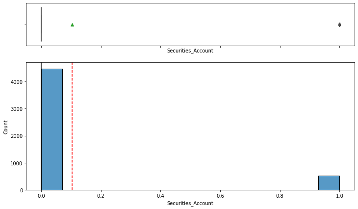

```python
histogram_boxplot(loan, 'Securities_Account')
```

- The numbers look very similiar to Personal Loan from above with nearly 500 having a Securities Account and around 4500 who do not
- It will be interesting to see if having a Securities Account has any correlation with accepting a Personal Loan

# CD Account

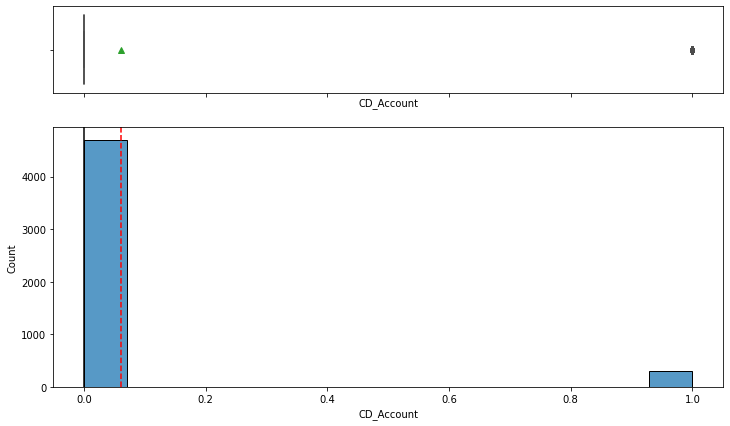

```python
histogram_boxplot(loan, 'CD_Account')
```

- Again very similiar numbers to Personal Loans, and Securities Account, but with even less having a CD Account

# Online

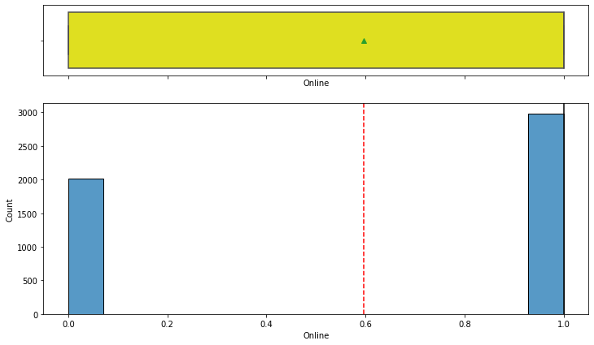

```python
histogram_boxplot(loan, 'Online')
```

- It looks like about 3,000 customers use online banking services, while the other 2,000 do not

# CreditCard

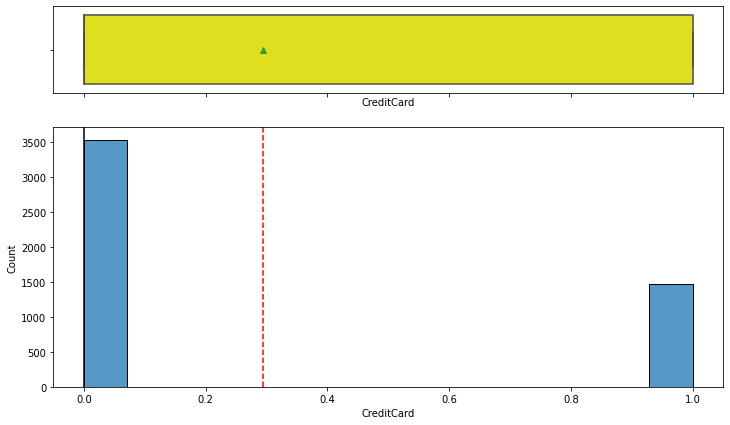

```python
histogram_boxplot(loan, 'CreditCard')
```

- Only about 1,500 have a credit card issued by another bank

# County

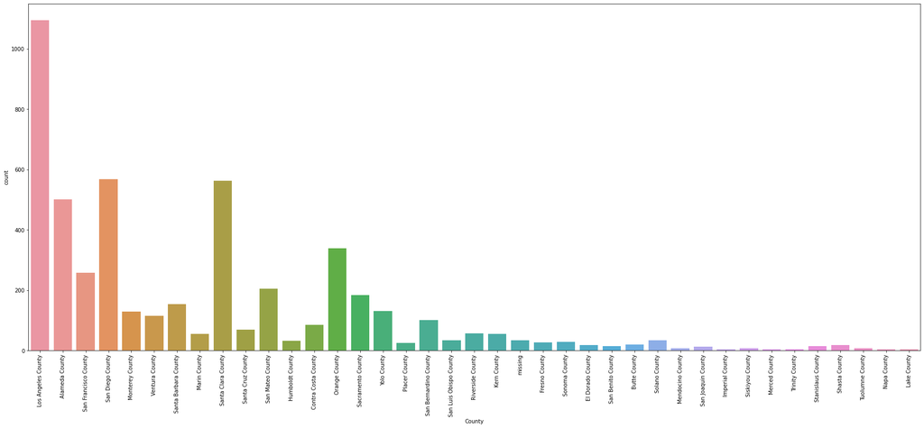

```python
plt.figure(figsize=(30,12))
sns.countplot(x=loan['County'])
plt.xticks(rotation=90)
plt.show()
```

- Los Angeles county has a disproportionately higher amount of customers with over a 1,000 being from that county. This means a little over 20% of customers are from one county.
- The next highest are San Diego and Santa Clara counties with about 600 customers in each.
- Most counties have less than 200 with some having even less than 10

```python
# Here are the actual counts per county
loan['County'].value_counts()
```

```
Los Angeles County        1095
San Diego County           568
Santa Clara County         563
Alameda County             500
Orange County              339
San Francisco County       257
San Mateo County           204
Sacramento County          184
Santa Barbara County       154
Yolo County                130
Monterey County            128
Ventura County             114
San Bernardino County      101
Contra Costa County         85
Santa Cruz County           68
Riverside County            56
Marin County                54
Kern County                 54
missing                     34
Solano County               33
San Luis Obispo County      33
Humboldt County             32
Sonoma County               28
Fresno County               26
Placer County               24
Butte County                19
Shasta County               18
El Dorado County            17
Stanislaus County           15
San Benito County           14
San Joaquin County          13
Mendocino County             8
Siskiyou County              7
Tuolumne County              7
Merced County                4
Trinity County               4
Lake County                  4
Imperial County              3
Napa County                  3
Name: County, dtype: int64
```

# Bivariate Analysis

```python
def stacked_barplot(data, predictor, target):
    """
    Print the category counts and plot a stacked bar chart

    data: loan
    predictor: independent variable
    target: target variable
    """
    count = loan[predictor].nunique()
    sorter = loan[target].value_counts().index[-1]
    tab1 = pd.crosstab(loan[predictor], loan[target], margins=True).sort_values(
        by=sorter, ascending=False
    )
    print(tab1)
    print('-' * 120)
    tab = pd.crosstab(loan[predictor], loan[target], normalize='index').sort_values(
        by=sorter, ascending=False
    )
    tab.plot(kind='bar', stacked=True, figsize=(count + 5, 6))
    plt.legend(
        loc='lower left', frameon=False
    )
    plt.legend(loc='upper left', bbox_to_anchor=(1, 1))
    plt.show()
```

# Age vs Personal Loan

```
Personal_Loan     0    1   All
Age
All            4520  480  5000
34              116   18   134
30              119   17   136
36               91   16   107
63               92   16   108
35              135   16   151
33              105   15   120
52              130   15   145
29              108   15   123
54              128   15   143
43              134   15   149
42              112   14   126
56              121   14   135
```

[output cut: 34 more lines]

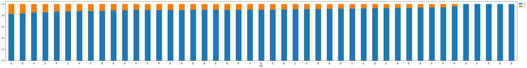

```python
stacked_barplot(loan, 'Age', 'Personal_Loan')
```

- 34, 30, and 36 were the top 3 age groups with the most number of customers taking loans
- Ages 23, 24, and 25 are the youngest 3 ages and no sutomers in these age groups accepted a personal loan

# Experience vs Personal Loan

```
Personal_Loan     0    1   All
Experience
All            4520  480  5000
9.0             127   20   147
8.0             101   18   119
3.0             112   17   129
20.0            183   17   200
12.0             86   16   102
5.0             132   14   146
32.0            140   14   154
26.0            120   14   134
25.0            128   14   142
19.0            121   14   135
16.0            114   13   127
37.0            103   13   116
35.0            130   13   143
30.0            113   13   126
23.0            131   13   144
22.0            111   13   124
11.0            103   13   116
31.0             92   12   104
36.0            102   12   114
6.0             107   12   119
18.0            125   12   137
7.0             109   12   121
29.0            112   12   124
28.0            127   11   138
17.0            114   11   125
13.0            106   11   117
21.0            102   11   113
39.0             75   10    85
34.0            115   10   125
27.0            115   10   125
4.0             104    9   113
2.0              76    9    85
24.0            123    8   131
1.0              66    8    74
38.0             80    8    88
41.0             36    7    43
10.0            111    7   118
33.0            110    7   117
0.0              59    7    66
14.0            121    6   127
15.0            114    5   119
40.0             53    4    57
42.0              8    0     8
43.0              3    0     3
------------------------------------------------------------------------------------------------------------------------
```

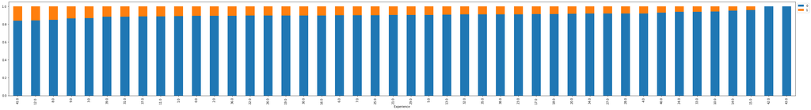

```python
stacked_barplot(loan, 'Experience', 'Personal_Loan')
```

# Income vs Personal Loan

```
Personal_Loan     0    1   All
Income
All            4520  480  5000
130               8   11    19
182               2   11    13
158               8   10    18
135               8   10    18
179               8    9    17
141              15    9    24
154              12    9    21
123               9    9    18
184               3    9    12
142               7    8    15
131              11    8    19
129              15    8    23
```

[output cut: 151 more lines]

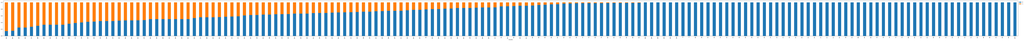

```python
stacked_barplot(loan, 'Income', 'Personal_Loan')
```

- There are a bunch of income levels that did not have anyone accept, as of those that did accept the income ranges are pretty diverse.
- Nobody with income less than 60,000 accepted a personal loan

# Family vs Personal Loan

```
Personal_Loan     0    1   All
Family
All            4520  480  5000
4              1088  134  1222
3               877  133  1010
1              1365  107  1472
2              1190  106  1296
------------------------------------------------------------------------------------------------------------------------
```

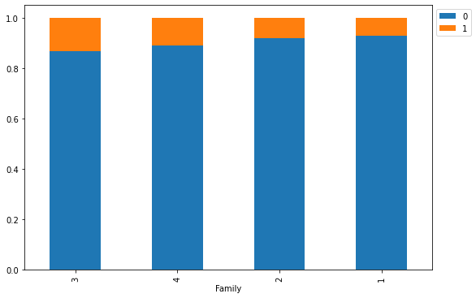

```python
stacked_barplot(loan, 'Family', 'Personal_Loan')
```

- 3 person families has a higher percentage of customers who accepted a loan, followed by 4 person, then a lower rate at 2, and 1 had the least.
- This shows that customers with families, either kids or just more family members living in their households, are more likely to take a personal loan offer.

# CCAvg vs Personal Loan

```
Personal_Loan     0    1   All
CCAvg
All            4520  480  5000
3.0              34   19    53
4.1               9   13    22
3.4              26   13    39
3.1               8   12    20
4.2               0   11    11
5.4               8   10    18
6.5               8   10    18
3.8              33   10    43
3.6              17   10    27
3.3              35   10    45
5.0               9    9    18
3.9              18    9    27
2.9              45    9    54
2.6              79    8    87
6.0              18    8    26
4.4               9    8    17
4.3              18    8    26
0.2             196    8   204
0.5             155    8   163
4.7              17    7    24
5.2               9    7    16
1.3             121    7   128
2.7              51    7    58
3.7              18    7    25
1.1              77    7    84
5.6               0    7     7
4.0              26    7    33
2.2             123    7   130
4.8               0    7     7
5.1               0    6     6
0.7             163    6   169
6.1               8    6    14
1.2              60    6    66
3.5               9    6    15
4.6               8    6    14
0.3             235    6   241
0.8             182    5   187
```

[output cut: 57 more lines]

```
2.75              0    1     1
2.67             36    0    36
0.67             18    0    18
0.75              9    0     9
4.33              9    0     9
8.6               8    0     8
6.67              9    0     9
1.33              9    0     9
6.7               9    0     9
1.67             18    0    18
1.75              9    0     9
7.8               9    0     9
7.6               9    0     9
2.33             18    0    18
------------------------------------------------------------------------------------------------------------------------
```

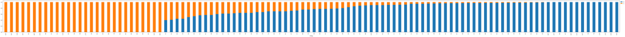

```python
stacked_barplot(loan, 'CCAvg', 'Personal_Loan')
```

# Education vs Personal Loan

```
Personal_Loan     0    1   All
Education
All            4520  480  5000
3              1296  205  1501
2              1221  182  1403
1              2003   93  2096
------------------------------------------------------------------------------------------------------------------------
```

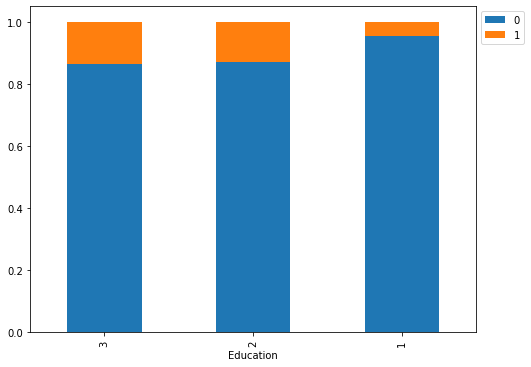

```python
stacked_barplot(loan, 'Education', 'Personal_Loan')
```

- The customers with an Advanced/Professional education had the highest amount of loan acceptance.
- Graduate level education was a close 2nd
- Undergraduate level customers only had about half the amount of loans accepted compared to Graduate level.
- This seems to show that the higher the level of customer education, the more likely they are to take a pesonal loan.

# Mortgage vs Personal_Loan

```
Personal_Loan     0    1   All
Mortgage
All            4520  480  5000
0              3150  312  3462
1              1370  168  1538
------------------------------------------------------------------------------------------------------------------------
```

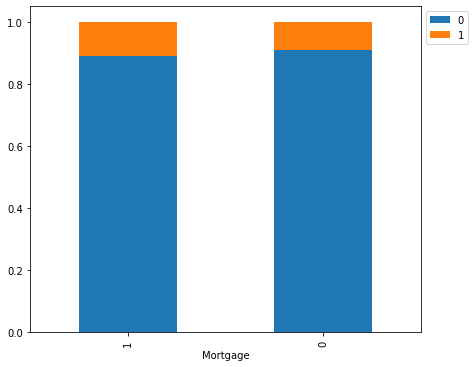

```python
stacked_barplot(loan, 'Mortgage', 'Personal_Loan')
```

- Those without a mortgage have about twice the amount of personal loans as those without.
- Which seems like it might be a significant factor but based on the overall ratio it is actually about a 10% acceptance rate for both.

# Securities_Account

```
Personal_Loan          0    1   All
Securities_Account
All                 4520  480  5000
0                   4058  420  4478
1                    462   60   522
------------------------------------------------------------------------------------------------------------------------
```

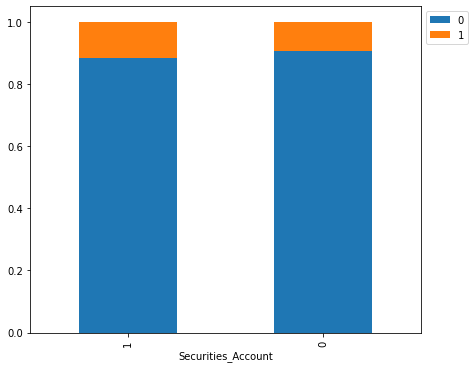

```python
stacked_barplot(loan, 'Securities_Account', 'Personal_Loan')
```

- There are many more customers without a Securities account that accepted a loan but that is also because the majority of customers don't have a Securities account.

# CD Account vs Personal Loan

```
Personal_Loan     0    1   All
CD_Account
All            4520  480  5000
0              4358  340  4698
1               162  140   302
------------------------------------------------------------------------------------------------------------------------
```

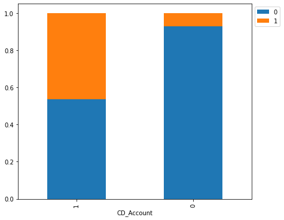

```python
stacked_barplot(loan, 'CD_Account', 'Personal_Loan')
```

- There are a higher number of personal loans accepted by customers without a CD Account but that is expected as the overwhelming majority of customers do not have a CD Account.
- More noteable though is that almost half of the customers with a CD Account also accepted a personal loan. There may be a correlation between having a CD Account and the likelihood that one would accept a personal loan, but further analysis will be required to see if this has any correlation.

# Online vs Personal Loan

```
Personal_Loan     0    1   All
Online
All            4520  480  5000
1              2693  291  2984
0              1827  189  2016
------------------------------------------------------------------------------------------------------------------------
```

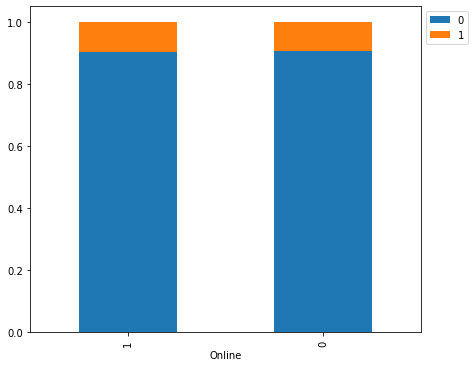

```python
stacked_barplot(loan, 'Online', 'Personal_Loan')
```

- There are more customers who use online banking services that accepted personal loans vs those that do not use online services, but there are more customers using online services overall so this isn't a very telling statistic.
- Looking at it further it is roughly a 10% acceptance rate for personal loans amongst both those that do use online services and those who do not.

# Credit Card vs Personal Loan

```
Personal_Loan     0    1   All
CreditCard
All            4520  480  5000
0              3193  337  3530
1              1327  143  1470
------------------------------------------------------------------------------------------------------------------------
```

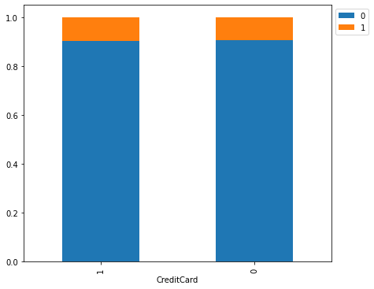

```python
stacked_barplot(loan, 'CreditCard', 'Personal_Loan')
```

# County vs Personal Loan

```
Personal_Loan              0    1   All
County
All                     4520  480  5000
Los Angeles County       984  111  1095
Santa Clara County       492   71   563
San Diego County         509   59   568
Alameda County           456   44   500
Orange County            309   30   339
San Francisco County     238   19   257
Monterey County          113   15   128
Sacramento County        169   15   184
Contra Costa County       73   12    85
San Mateo County         192   12   204
Ventura County           103   11   114
Santa Barbara County     143   11   154
Yolo County              122    8   130
Santa Cruz County         60    8    68
Kern County               47    7    54
Sonoma County             22    6    28
Marin County              48    6    54
Riverside County          50    6    56
San Luis Obispo County    28    5    33
Shasta County             15    3    18
missing                   31    3    34
Solano County             30    3    33
San Bernardino County     98    3   101
Butte County              17    2    19
Placer County             22    2    24
Fresno County             24    2    26
Humboldt County           30    2    32
San Joaquin County        12    1    13
El Dorado County          16    1    17
Stanislaus County         14    1    15
Mendocino County           7    1     8
Imperial County            3    0     3
San Benito County         14    0    14
Siskiyou County            7    0     7
Napa County                3    0     3
Merced County              4    0     4
Trinity County             4    0     4
Tuolumne County            7    0     7
Lake County                4    0     4
------------------------------------------------------------------------------------------------------------------------
```

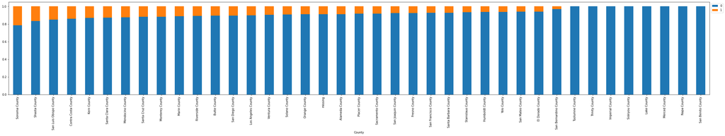

```python
stacked_barplot(loan, 'County', 'Personal_Loan')
```

- As far as actual number of customers who accepted personal loans, it seems to correlate to the total number of customers per county with some exceptions.
- The exceptions though is where the higher percentages are seen, such as Sonoma County having a little over a 21% acceptance rate. So while this acceptance rate is quite high, there are only 28 customers in Sonoma County which means only 6 customers from Sonoma accepted personal loans.
- Shasta County is also similar as it has about a 17% acceptance rate, but only 18 customers total with 3 accepting personal loans.
- Compare this to Los Angeles County which has the highest number of customers who accepted personal loans at 111, but this is out of 1095 customers in Los Angeles County, so it is only a 10% acceptance rate.
- It will be interesting which has more of a correlation, if any, between the actual number of accepted loans per county vs. the acceptance rate percentage per county.

# Heatmap

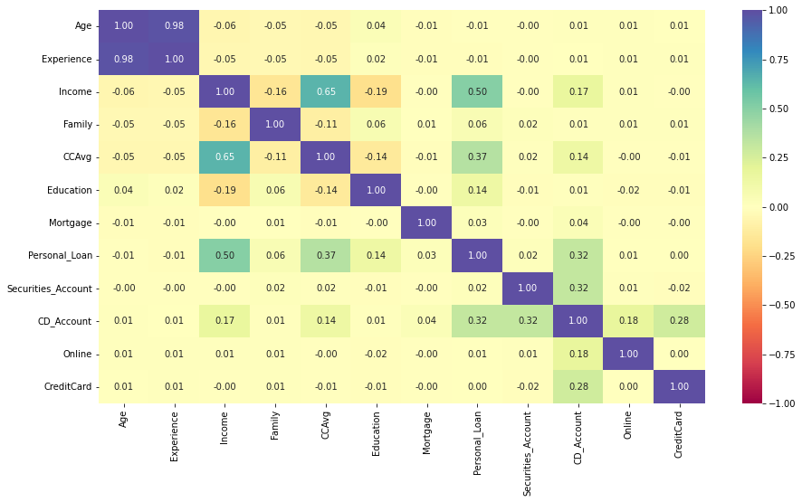

```python
plt.figure(figsize=(15, 8))
sns.heatmap(loan.corr(), annot=True, vmin=-1, vmax=1, fmt='.2f', cmap='Spectral')
plt.show()
```

- Experience and Age have a 0.98 correlation but that is because years of working experience should increase with age so no surprise here.
- The next highest correlation is 0.65 between income and the average amount of credit card spending per month. I would think those with higher income wouldn't be spending more on credit cards per month, but I suppose many do so for the rewards and cash back they earn by spending and paying it off each month so I can see why there is some correlation.
- The the only other one with some signifigance appers to be 0.50 between income and personal loans, showing that there is somewhat of a correlation between higher income and the likelihood of accepting a personal loan. We did see this earlier in the stacked bar plot where it showed that no one who makes under 60,000 per year accepted a personal loan.

# Summary of EDA

- Based on the EDA you want to look at customers over the age of 25, as customers who are 23, 24, and 25 years old did not accept any personal loans.
- You would also want to look at customers making over 60,000 a year as no one making less than that accepted a personal loan.
- Education shows that customers who have an advanced/Professional level of education have the highest number of customers who accepted personal loans.
- You may also want to look at customers with 3 person families as that was the highest family category amongst customers accepting personal loans.
- One factore that seems like it may have a stronger influence is whether or not a customer has a CD Account with the bank, as there was a 50% acceptance rate of personal loans for those customers having a CD Account.
- Certain counties may have an influence such as Sonoma County or Shasta County as they had higher acceptance rates, but overall, the actual number of customers with personal loans from those counties were not large amounts.
- So as of right now, just based on EDA, the customers to focues on would be those over 25, with a 3 person family, having an advanced/professional education, earning more than 60,000 per yer year, who currently have a CD Account with the bank, and are possibly from a county with a higher acceptance rate for personal loans such as Sonoma or Shasta county.
- It will be interesting to see if any of these facotrs turn out to be the ones influencing personal loans and how close these demographic perdictions might be once we get results from our model.

# Model Building

```python
#function to check metrics

def model_perf_class_sklearn_threshold(model, predictors, target, threshold=0.5):
    """
    Function to calculate metrics, based on specified threshold, and check classification model performance

    model: classifier
    predictors: independent variables
    target: dependent variable
    threshold: threshold for classifying the observation as class 1
    """

    # predict with independent variables
    pred_prob = model.predict_proba(predictors)[:, 1]
    pred_thresh = pred_prob > threshold
    pred = np.round(pred_thresh)

    acc = accuracy_score(target, pred)
    recall = recall_score(target, pred)
    precision = precision_score(target, pred)
    f1 = f1_score(target, pred)

    # create a df for metrics
    df_perf = pd.DataFrame(
        {
          'Accuracy': acc,
          'Recall': recall,
          'Precision': precision,
          'F1': f1
        },
        index=[0]
    )

    return df_perf
```

```python
#function for confusion_matrix
def confusion_matrix_sklearn_threshold(model, predictors, target, threshold=0.5):
    """
    Plot confusion_matrix, based on specified threshold, with percentages

    model: classifier
    predictors: independent variables
    target: dependent variable
    threshold: threshold for classifying observation as class 1
    """
    pred_prob = model.predict_proba(predictors)[:, 1]
    pred_thresh = pred_prob > threshold
    y_pred = np.round(pred_thresh)

    cm = confusion_matrix(target, y_pred)
    labels = np.asarray(
        [
            ['{0:0.0f}'.format(item) + '\n{0:.2%}'.format(item / cm.flatten().sum())]
            for item in cm.flatten()
        ]
    ).reshape(2, 2)

    plt.figure(figsize=(6,4))
    sns.heatmap(cm, annot=labels, fmt='')
    plt.ylabel('True label')
    plt.xlabel('Predicted label')
```

## Data Prep

```python
X = loan.drop('Personal_Loan', axis=1)
y = loan['Personal_Loan']

# creating dummy variables
X = pd.get_dummies(X, drop_first=True)

# splitting in training and test set
X_train, X_test, y_train, y_test = train_test_split(
    X, y, test_size=0.3, random_state=42
)
```

# Logistic Regression

```python
# We will use the newton-cg solver as it is faster for high-dimensional data
model = LogisticRegression(solver='newton-cg', random_state=1)
lg = model.fit(X_train, y_train)
```

# Finding the coefficients

```python
log_odds = lg.coef_[0]
pd.DataFrame(log_odds, X_train.columns, columns=['coef']).T
```

|  | Age | Experience | Income | Family | CCAvg | Education | Mortgage | Securities_Account | CD_Account | Online | CreditCard | County_Butte County | County_Contra Costa County | County_El Dorado County | County_Fresno County | County_Humboldt County | County_Imperial County | County_Kern County | County_Lake County | County_Los Angeles County | County_Marin County | County_Mendocino County | County_Merced County | County_Monterey County | County_Napa County | County_Orange County | County_Placer County | County_Riverside County | County_Sacramento County | … |
| --- | --- | --- | --- | --- | --- | --- | --- | --- | --- | --- | --- | --- | --- | --- | --- | --- | --- | --- | --- | --- | --- | --- | --- | --- | --- | --- | --- | --- | --- | --- |
| coef | 0.061493 | -0.050879 | 0.053326 | 0.701097 | 0.103979 | 1.563387 | 0.16335 | -0.722529 | 3.10554 | -0.474361 | -0.93923 | 0.240272 | -0.010132 | -0.186542 | -0.222027 | -0.436752 | -0.023641 | 0.560879 | -0.007809 | 0.17264 | 0.002981 | -0.075351 | -0.346514 | -0.198929 | -0.00373 | -0.021401 | -0.396811 | 0.969385 | -0.287877 | … |

# Odds from coefficients

```python
# Coefficients are log(odd), so we will take the exponential to get odds
odds = np.exp(lg.coef_[0])

# percentage change
perc_change_odds = (np.exp(lg.coef_[0]) - 1) * 100

# create a df for odds
pd.DataFrame({'Odds': odds, 'Change_odd%': perc_change_odds}, index=X_train.columns).T
```

|  | Age | Experience | Income | Family | CCAvg | Education | Mortgage | Securities_Account | CD_Account | Online | CreditCard | County_Butte County | County_Contra Costa County | County_El Dorado County | County_Fresno County | County_Humboldt County | County_Imperial County | County_Kern County | County_Lake County | County_Los Angeles County | County_Marin County | County_Mendocino County | County_Merced County | County_Monterey County | County_Napa County | County_Orange County | County_Placer County | County_Riverside County | County_Sacramento County | … |
| --- | --- | --- | --- | --- | --- | --- | --- | --- | --- | --- | --- | --- | --- | --- | --- | --- | --- | --- | --- | --- | --- | --- | --- | --- | --- | --- | --- | --- | --- | --- |
| Odds | 1.063423 | 0.950394 | 1.054774 | 2.015964 | 1.109578 | 4.774965 | 1.177449 | 0.485523 | 22.321277 | 0.622283 | 0.390929 | 1.271595 | 0.989919 | 0.829824 | 0.800894 | 0.646131 | 0.976636 | 1.752212 | 0.992221 | 1.188439 | 1.002986 | 0.927418 | 0.707149 | 0.819608 | 0.996277 | 0.978826 | 0.672461 | 2.636323 | 0.749854 | … |
| Change_odd% | 6.342286 | -4.960643 | 5.477356 | 101.596398 | 10.957753 | 377.496504 | 17.744929 | -51.447732 | 2132.127684 | -37.771742 | -60.907116 | 27.159507 | -1.008118 | -17.017622 | -19.910604 | -35.386866 | -2.336373 | 75.221172 | -0.777868 | 18.843877 | 0.298592 | -7.258205 | -29.285097 | -18.039157 | -0.372313 | -2.117410 | -32.753887 | 163.632277 | -25.014618 | … |

# Odds Observations

Some of the more notable odds are:

- Family: Holding all other features constant a unit change in Family will increase the odds of a customer accepting a personal loan by 2.02 times or a 101.60% increase in the odds.
- Education: Holding all other features constant a unit change in Education will increase the odds of a customer being accepting a personal loan by 4.77 times or a 377.50% increase in the odds.
- CD_Account: Holding all other features constant having a CD_Account will increase the odds of a customer accepting a personal loan by 22.32 times or a 2132.13% increase in the odds.
- Riverside and Solano counties both show over a 100% increase in odds
- As far as negative change in odds 64.15% is the largest amount for a decrease in odds and this is with the coefficient for San Mateo County.
- The negative changes have much lower changes in odd % comparitvely when looking at the positive changes in odd %

# Checking model performance on training set

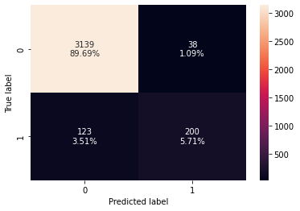

```python
# create confusion matrix
confusion_matrix_sklearn_threshold(lg, X_train, y_train)
```

```python
log_reg_model_train_perf = model_perf_class_sklearn_threshold(
    lg, X_train, y_train
)

print('Training Performance:')
log_reg_model_train_perf
```

```
Training Performance:
```

|  | Accuracy | Recall | Precision | F1 |
| --- | --- | --- | --- | --- |
| 0 | 0.954 | 0.619195 | 0.840336 | 0.713012 |

# ROC-AUC

- ROC-AUC on training set

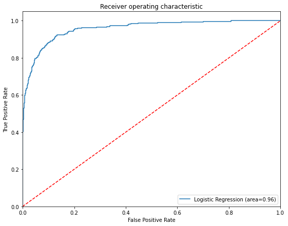

```python
logit_roc_auc_train = roc_auc_score(y_train, lg.predict_proba(X_train)[:, 1])
fpr, tpr, thresholds = roc_curve(y_train, lg.predict_proba(X_train)[:, 1])
plt.figure(figsize=(9, 7))
plt.plot(fpr, tpr, label = "Logistic Regression (area=%0.2f)" % logit_roc_auc_train)
plt.plot([0, 1], [0, 1], 'r--')
plt.xlim([0.0, 1.0])
plt.ylim([0.0, 1.05])
plt.xlabel('False Positive Rate')
plt.ylabel('True Positive Rate')
plt.title('Receiver operating characteristic')
plt.legend(loc='lower right')
plt.show()
```

- Logistic Regression model shows good performance on the training set, but the recall is lower than I'd like it be.